# Regression and model validation

# 1. Reading the data into R

Reading the data collected from students in 2014 into R

```r
learning2014 <- read.table("C:/Data/IODS-project/learning2014.csv", sep=";", header=TRUE)
```

Looking at the dimensions of the data (first value will be the number of rows (observations), second will be columns (variables))

```r
dim(learning2014)
```

```
## [1] 166   7
```

Looking at the structure of the data

```r
str(learning2014)
```

```
## 'data.frame':    166 obs. of  7 variables:
##  $ gender  : Factor w/ 2 levels "F","M": 1 2 1 2 2 1 2 1 2 1 ...
##  $ Age     : int  53 55 49 53 49 38 50 37 37 42 ...
##  $ Attitude: num  0.037 0.031 0.025 0.035 0.037 0.038 0.035 0.029 0.038 0.021 ...
##  $ deep    : num  3.58 2.92 3.5 3.5 3.67 ...
##  $ stra    : num  3.38 2.75 3.62 3.12 3.62 ...
##  $ surf    : num  2.58 3.17 2.25 2.25 2.83 ...
##  $ Points  : int  25 12 24 10 22 21 21 31 24 26 ...
```

# 2. Graphical view of the data

Accessing the ggplot2 library for displaying plots of data

```r
library(ggplot2)
```

Drawing a scatter plot matrix of all the variables in the dataset

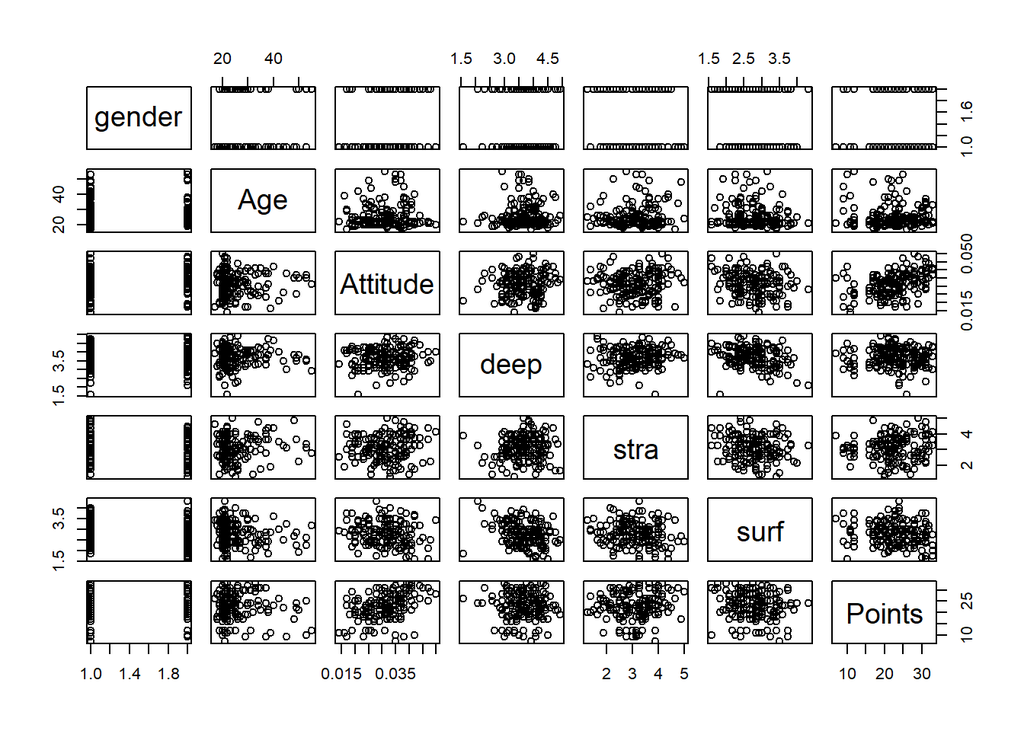

```r
pairs(learning2014)
```

Drawing another same scatter plot excluding gender variable

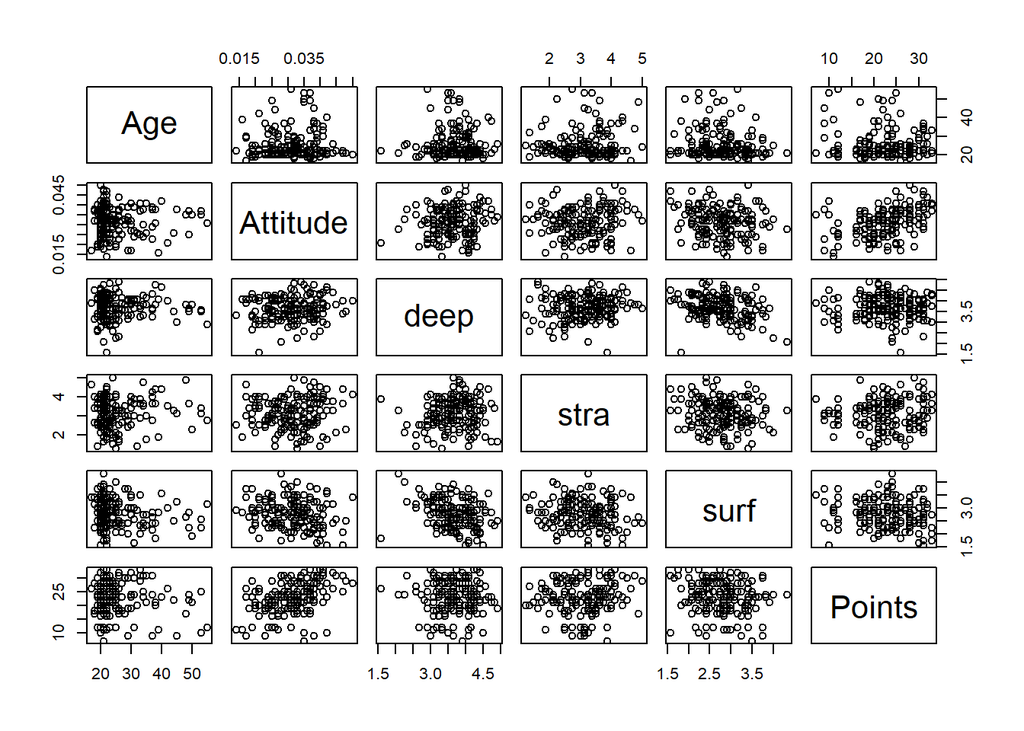

```r
pairs(learning2014[-1])
```

Coloring the variable “gender”"

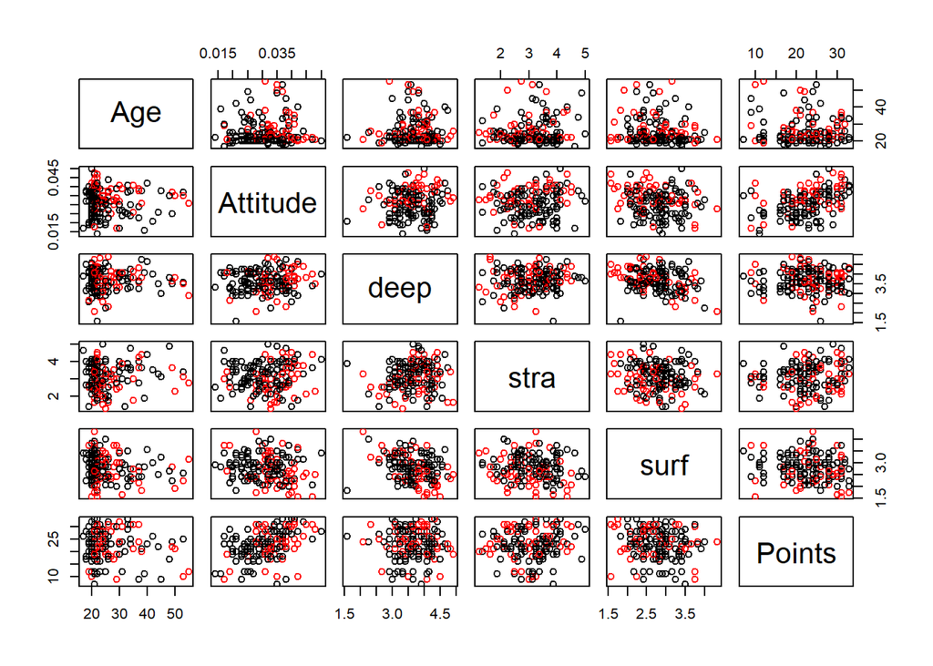

```r
pairs(learning2014[-1], col = learning2014$gender)
```

Accessing the GGally library to draw more advanced plots

```r
library(GGally)
```

Creating a plot matrix with ggpair, where we can see the distribution of the variables and their correlation with one another

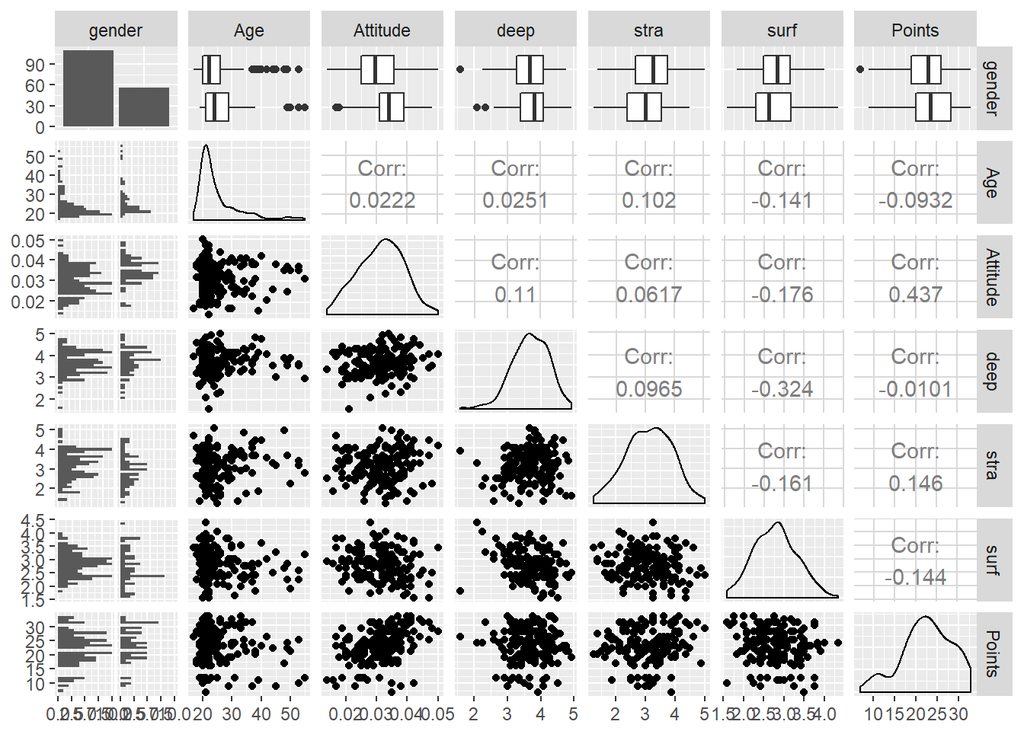

```r
p <- ggpairs(learning2014)
p
```

As can be seen from the plot most variables have noramal distribution except “age”, the distribution of which is positively skewed. The distribution of “Points” is also skewed negatively.

“Attitude” and “Exam points”" exhibit the highest (positive) correlation, which is reasonable. As your attitute is more positive toward statistics, you are more likely to get a better point.

So, now let’s now look at the scatter plot of points versus attitude

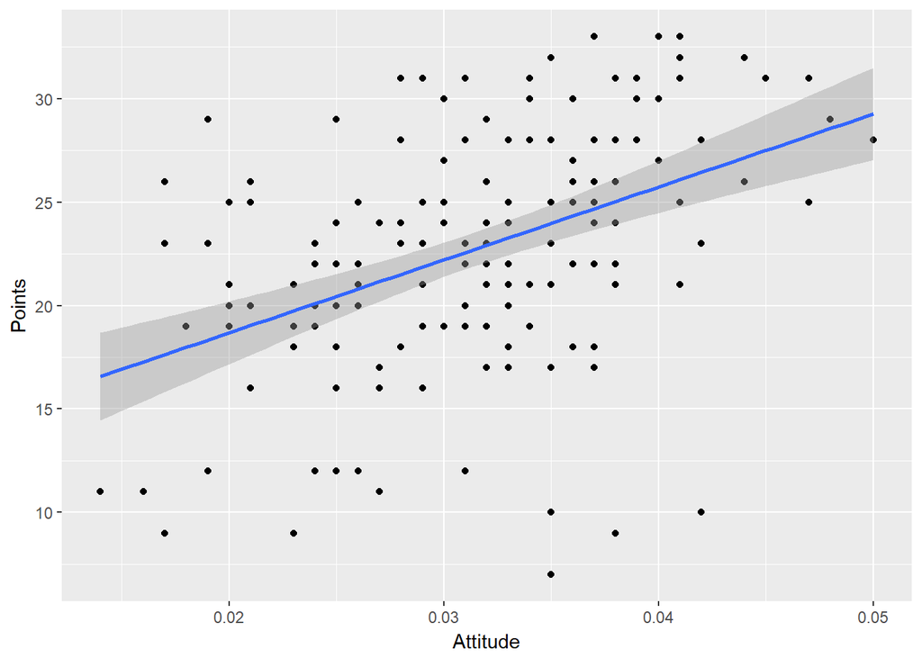

```r
qplot(Attitude, Points, data = learning2014) + geom_smooth(method = "lm")
```

And, now let’s fit a linear model, and call it ‘my_model’

```r
my_model <- lm(Points ~ Attitude, data = learning2014)
```

Now, let’s print out a summary of the model

```r
summary(my_model)
```

```
##
## Call:
## lm(formula = Points ~ Attitude, data = learning2014)
##
## Residuals:
##      Min       1Q   Median       3Q      Max
## -16.9763  -3.2119   0.4339   4.1534  10.6645
##
## Coefficients:
##             Estimate Std. Error t value Pr(>|t|)
## (Intercept)    11.64       1.83   6.358 1.95e-09 ***
## Attitude      352.55      56.74   6.214 4.12e-09 ***
## ---
## Signif. codes:  0 '***' 0.001 '**' 0.01 '*' 0.05 '.' 0.1 ' ' 1
##
## Residual standard error: 5.32 on 164 degrees of freedom
## Multiple R-squared:  0.1906, Adjusted R-squared:  0.1856
## F-statistic: 38.61 on 1 and 164 DF,  p-value: 4.119e-09
```

The summary indicates that there is a statistically significant positive relationship between Attitude and Points, with P-value of under 0.001. Also F-statistics of the model is high enough.

Other variables which display positive correlations are, e.g., “Attitude” and “deep learning”, “strategic learning” and “Age”. Unsurprisingly, there is a negative correlation (-0.32) between “surface learning” and “deep learning”.

Creating a more advanced plot matrix with ggpairs

```r
p <- ggpairs(learning2014, mapping = aes(col = gender, alpha = 0.3), lower = list(combo = wrap ("facethist", bins = 20)))
```

Drawing the new plot

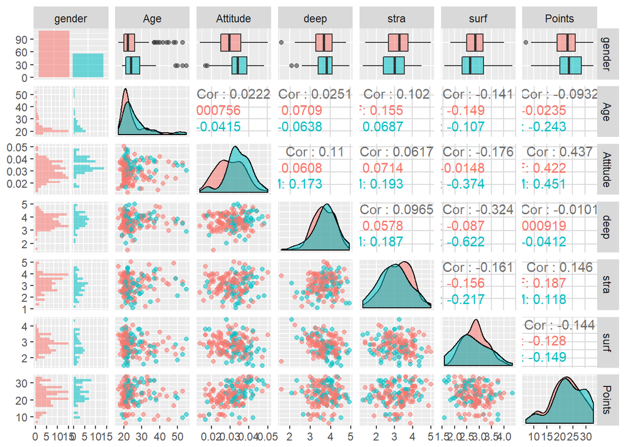

```r
p
```

This new plot shows differences between males and females in blueish and pinkish color, respectively. It also shows box plots of the variables for both males and females.

As an example, we can now see that attitude of male students toward learning statistics is a bit more positive compared to their females classmates, hence the positive skewness of the distribution for male.

# 3. Multiple Regression Model

Creating a regression model with multiple explanatory variables (multiple regression). I use Points as the dependent variable (y), and Attitude, surface learning, and strategic learning as explanatory variables (X).

```r
my_model2 <- lm(Points ~ Attitude + stra + surf, data = learning2014)
```

Printg out a summary of the model

```r
summary(my_model2)
```

```
##
## Call:
## lm(formula = Points ~ Attitude + stra + surf, data = learning2014)
##
## Residuals:
##      Min       1Q   Median       3Q      Max
## -17.1550  -3.4346   0.5156   3.6401  10.8952
##
## Coefficients:
##             Estimate Std. Error t value Pr(>|t|)
## (Intercept)  11.0171     3.6837   2.991  0.00322 **
## Attitude    339.5221    57.4148   5.913 1.93e-08 ***
## stra          0.8531     0.5416   1.575  0.11716
## surf         -0.5861     0.8014  -0.731  0.46563
## ---
## Signif. codes:  0 '***' 0.001 '**' 0.01 '*' 0.05 '.' 0.1 ' ' 1
##
## Residual standard error: 5.296 on 162 degrees of freedom
## Multiple R-squared:  0.2074, Adjusted R-squared:  0.1927
## F-statistic: 14.13 on 3 and 162 DF,  p-value: 3.156e-08
```

As the summary of the model indicates, only Attitude has a statistically significant relationship with Points.

Now, let’s remove surface learning from the model, and call it my_model3

```r
my_model3 <- lm(Points ~ Attitude + stra, data = learning2014)
```

# 4. Summary of the multiple regression model

Let’s print out the new model

```r
summary(my_model3)
```

```
##
## Call:
## lm(formula = Points ~ Attitude + stra, data = learning2014)
##
## Residuals:
##      Min       1Q   Median       3Q      Max
## -17.6436  -3.3113   0.5575   3.7928  10.9295
##
## Coefficients:
##             Estimate Std. Error t value Pr(>|t|)
## (Intercept)   8.9729     2.3959   3.745  0.00025 ***
## Attitude    346.5810    56.5169   6.132 6.31e-09 ***
## stra          0.9137     0.5345   1.709  0.08927 .
## ---
## Signif. codes:  0 '***' 0.001 '**' 0.01 '*' 0.05 '.' 0.1 ' ' 1
##
## Residual standard error: 5.289 on 163 degrees of freedom
## Multiple R-squared:  0.2048, Adjusted R-squared:  0.1951
## F-statistic: 20.99 on 2 and 163 DF,  p-value: 7.734e-09
```

The model shows that still only attitude is siginificant. However, now the p-value of ‘stra’ is smaller (0.08).This value is smaller than 0.1, which is sometimes considered to indicate the statistical significance.

The model shows that “Attitude”" is positively and strongly correlates with “Points”. As explained earlier, this is reasonable, because those who have a more positive attitude toward sttistical learning will be more likely to receive a higher point (in a statstics test, e.g.). Also, there is a positive correlation between strategic learning and points students have received. This makes sense, too. The more strategic thinking oriented students are, the higher the probability of receiving a better grade. But the correlation is weak, yet could be considered significant.

R-squared of the model is ~ 0.20, which indicates that around 20 percent of the variance of the variables is explained by the regression model. Whether or not this value is acceptable depends on, e.g., the nature of the study and the dicsipline. As a general rule, the higher the R-squared the better the model, but this is not the case always. The adjusted R-squared is the same as R-squared but has been adjusted for the number of predictors in the model.

# 5. Diagnostic plots

Producing diagnostic plots

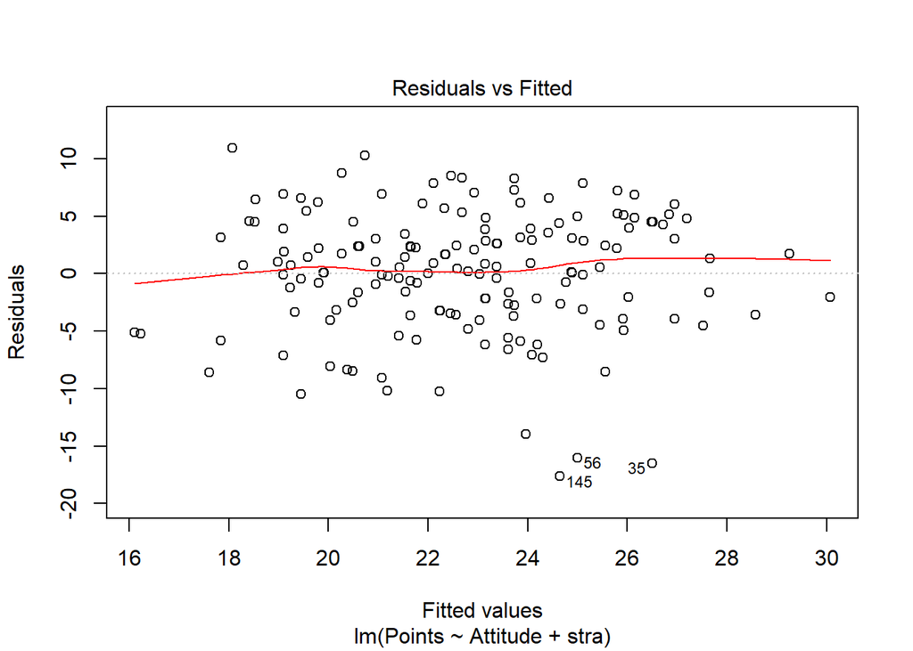

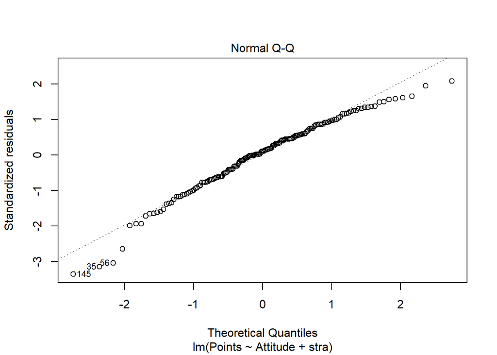

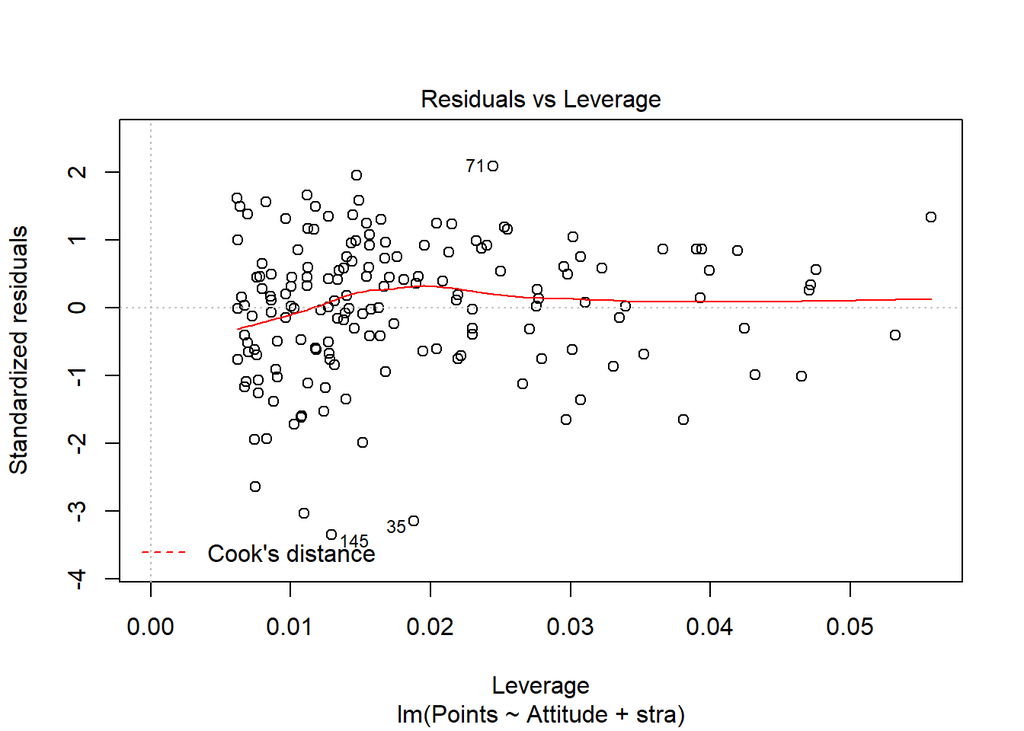

```r
plot(my_model3, which = c(1,2,5))
```

Now plots of Residuals vs. Fitted values (1), Normal QQ-plot (2), and Residuals vs. Leverage have been produced.

Now, let’s place all the above graphs to the same plots

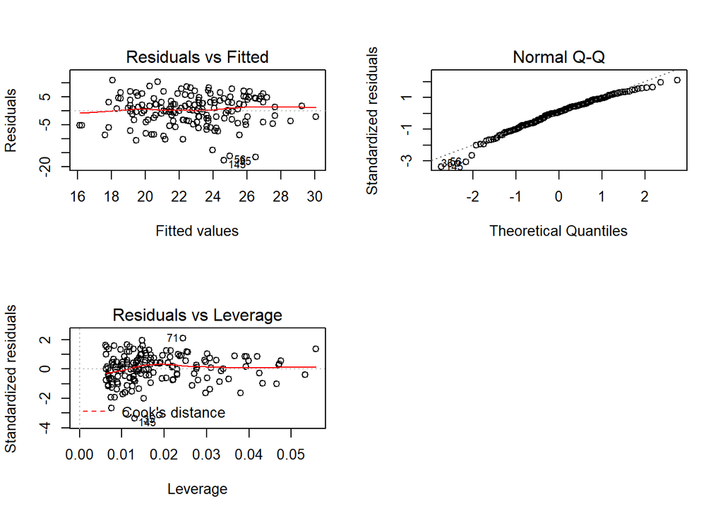

```r
par(mfrow = c(2,2))
plot(my_model3, which = c(1,2,5))
```

What do these plots indicate? Let’s first explore “Residuls vs Fitted values”. This plot is used to understand the linearity of the model, the unequality of error variance, and if there is any outliers. Looking at the plot reveals that the residuals are scattered rather randolmy around 0, and have formed a horizontal line, meaning that the relationship of the variables in our model is linear and also the errors are equal. Only there are some values that are far from the rest (lower side of the plot); these could be considered as outliers. How influential they are in our model will be determined by another plot, which we will look at soon.

These diagnostic plots explained above confirm the validity of our statistical model; that is, our model is linear, the variables are normally distributed, and there are no major influential outliers.